# Linear Regression Models: Logistic Regression

## Predictive Modeling

Broadly, can organize goals as

- Unsupervised learning - goal is to learn about patterns and relationships in the data
  - No output to shoot for
- Supervised learning - a variable or variables in the data set represent an 'output' of interest
  - May wish to make **inference** on the model
  - Often just want to predict response(s)

## Supervised Learning

Commonly used supervised methods are

- Regression models
  - Least squares
  - Penalized regression
  - Locally weighted/splines
  - Generalized linear models
- Tree based methods
  - Regression/classification trees
  - Random forests, boosting, bagging
- k Nearest Neighbors

… and many more, tons of methods!

## Predictive Modeling

Where to start?

- Not going to focus on inference (applied statistics sequence covers that well!)
- Start with basic linear regression models
- Expand to different *types* of responses in the **exponential family**
- Explore tree methods
- Look at ensemble type methods to improve prediction

Lastly, we'll look at some unsupervised methods like clustering and PCA

## Linear Regression Shortcomings

Standard linear regression models

- Assumption:
  - Response can take on any value on the real line
  - Think about an SLR model, prediction will be negative for some \(x\)
  - Often \(x\) that gives negative values not relevant so ok
- Assumption for inference:
  - Errors normally distributed
  - Allows for t-tests and F-tests
  - Constant variance assumed (may depend on mean)

When these are violated *Generalized Linear Models* can sometimes help!

## Generalized Linear Models

A note on names…

- General Linear Model (GLM):
  - Continuous response
  - Allows for both continuous and categorical predictors
- Generalized Linear Model (GLM):
  - Allows for responses from non-normal distributions
  - Can have both types of predictors
- Confusing!

## Generalized Linear Models

- Very common generalized linear model: Logistic Regression model
- Model for response that is success/failure - Visuals/summaries first!

```r
FGData <- read_sas("..\\datasets\\FG.sas7bdat")
FGData
```

```
## # A tibble: 17,104 x 8
##   gameid       kicker       outcome yards  year fgpct fgstrg  good
##   <chr>        <chr>        <chr>   <dbl> <dbl> <dbl> <chr>  <dbl>
## 1 200309070gnb Aaron Elling good       22  2003 0.679 19/28      1
## 2 200309070gnb Aaron Elling good       46  2003 0.679 19/28      1
## 3 200309070gnb Aaron Elling good       34  2003 0.679 19/28      1
## 4 200309140min Aaron Elling good       23  2003 0.679 19/28      1
## 5 200309140min Aaron Elling no good    53  2003 0.679 19/28      0
## # ... with 1.71e+04 more rows
```

## Success/Fail as Response

- Summarize made vs not made kicks

```r
tab <- table(FGData$good, cut(FGData$yards, c(17,27,37,47,57,77)))
rbind(tab, apply(tab, MARGIN = 2, FUN = function(x){round(x[2] / sum(x), 3)}))
```

```
##   (17,27]  (27,37]  (37,47]  (47,57] (57,77]
## 0  117.00  602.000 1307.000 1089.000  93.000
## 1 3820.00 4364.000 4027.000 1660.000  24.000
##      0.97    0.879    0.755    0.604   0.205
```

## Success/Fail as Response

- Summarize made vs not made kicks

```r
table(FGData$good, FGData$yards)
```

```
##
##      17  18  19  20  21  22  23  24  25  26  27  28  29  30  31  32  33
##   0   0   1   3   7  10  11  13  19  12  22  19  43  38  50  44  56  65
##   1   1  37 228 404 366 453 553 440 449 437 453 488 408 419 448 444 543
##
##      34  35  36  37  38  39  40  41  42  43  44  45  46  47  48  49  50
##   0  77  63  66 100 106  96 107 111 135 160 150 131 149 162 213 157 143
##   1 376 404 395 439 504 400 457 405 430 438 344 353 338 358 376 281 247
##
##      51  52  53  54  55  56  57  58  59  60  61  62  63  64  65  66  68
##   0 131 145 130  67  52  24  27  23  16  12  11   6   6   5   5   4   2
##   1 220 173 180  94  52  23  14   8   5   3   3   1   3   1   0   0   0
##
##      69  71  76
##   0   1   1   1
##   1   0   0   0
```

## Linear regression model not great here

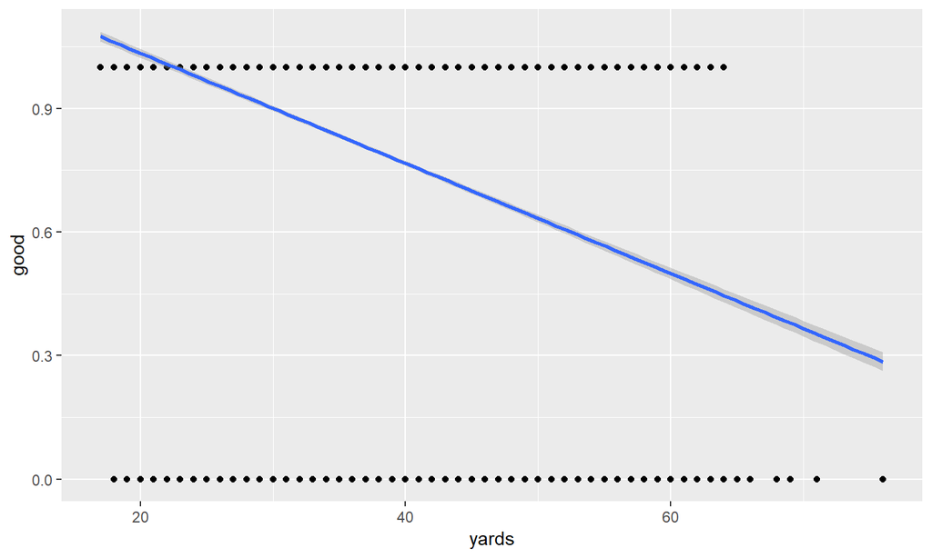

```r
ggplot(FGData, aes(x = yards, y = good)) + geom_point() +
    geom_smooth(method = "lm")
```

## Linear regression model not great here

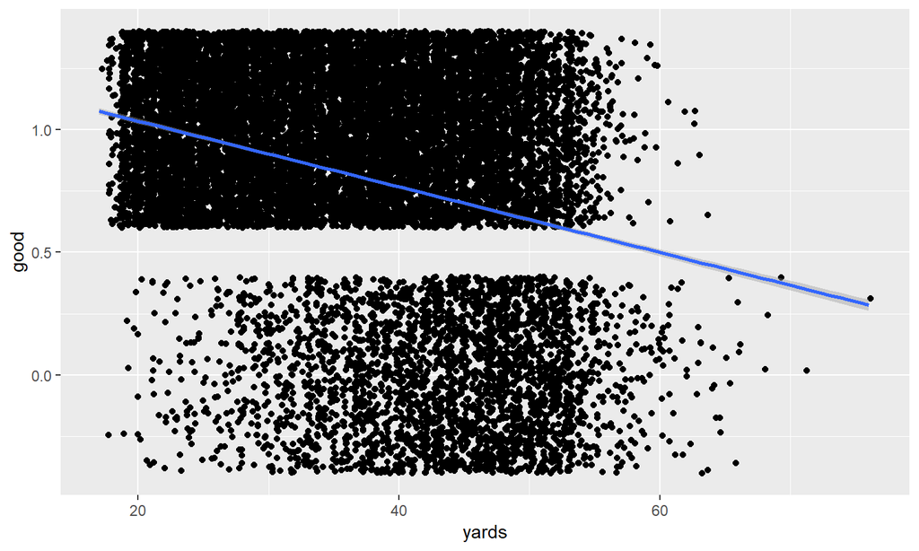

```r
ggplot(FGData, aes(x = yards, y = good)) + geom_jitter() +
    geom_smooth(method = "lm")
```

## Better View of Data

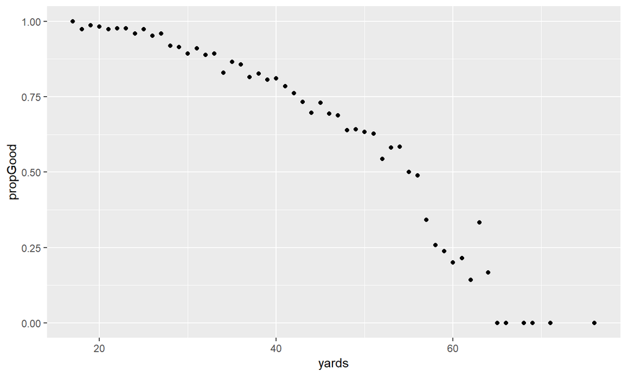

```r
distSum <- FGData %>% group_by(yards) %>% summarize(propGood = mean(good))
ggplot(distSum, aes(x = yards, y = propGood)) + geom_point(stat = "identity")
```

## Even Better View of Data

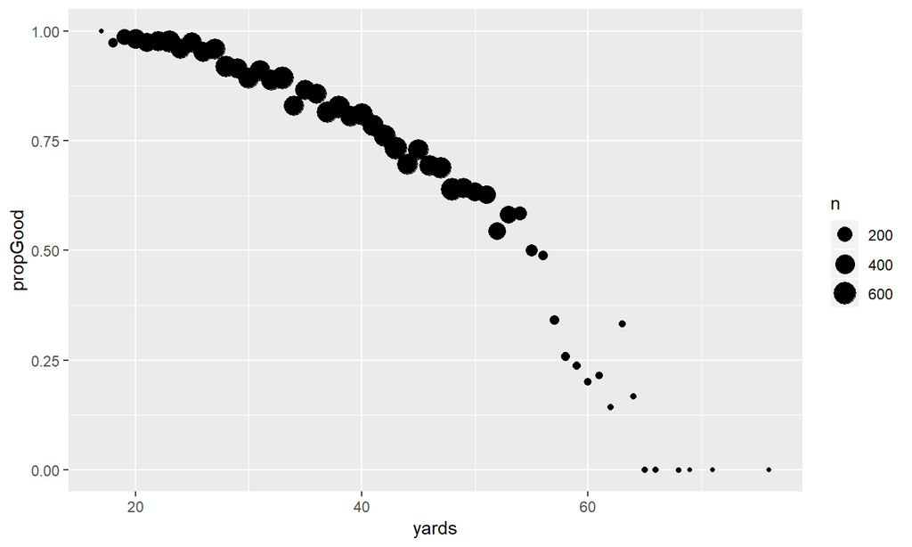

```r
distSum <- FGData %>% group_by(yards) %>% summarize(propGood = mean(good), n = n())
ggplot(distSum, aes(x = yards, y = propGood, size = n)) + geom_point(stat = "identity")
```

## Better View of Data

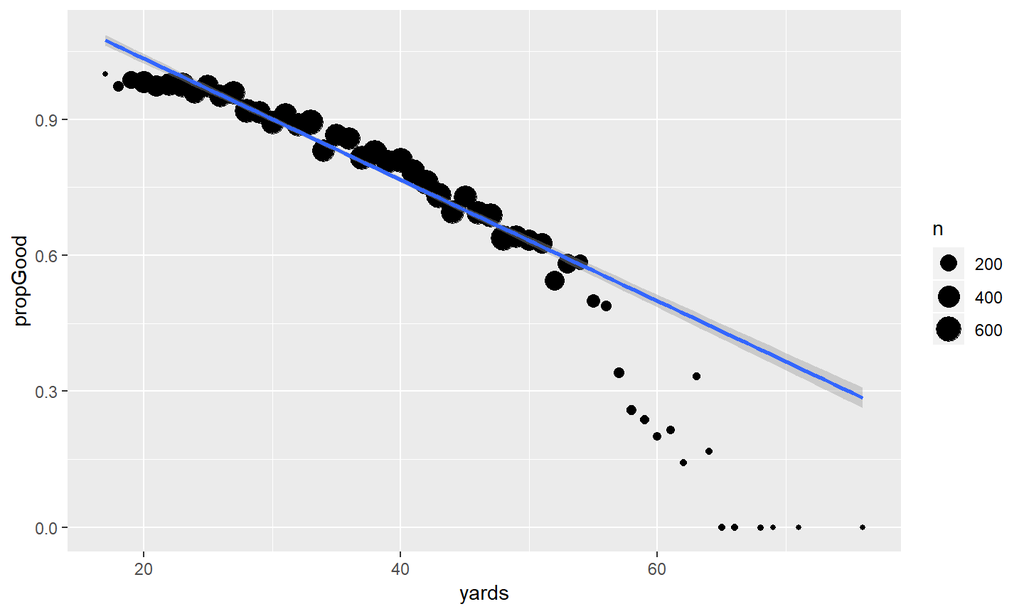

```r
ggplot(distSum, aes(x = yards, y = propGood)) + geom_point(stat = "identity", aes(size = n)) +
    geom_smooth(data = FGData, aes(x = yards, y = good), method = "lm")
```

## Success/Fail as Response

- Could use this for prediction (classification here) purposes

```r
betas <- coef(lm(good ~ yards, data = FGData))
betas
```

```
## (Intercept)       yards
##  1.30174041 -0.01337391
```

```r
uniroot(function(x){betas[1] + betas[2] * x - 0.5}, lower = 15, upper = 65)$root
```

```
## [1] 59.94807
```

- If above 59.9480717 predict a miss…

## Logistic Regression

- Since response is really success/failure –> modeling average number of successes for a given \(x\), i.e. probability of success
  - predictions should never go below 0
  - predictions should never go above 1
- Saw modeling \(P(success|yards)\) as a linear function not great
- Basic Logistic Regression models success probability using the *logistic function*

\[P(success|yards) = \frac{e^{\beta_0+\beta_1x}}{1+e^{\beta_0+\beta_1x}}\]

## Logistic Regression

\[P(success|yards) = \frac{e^{\beta_0+\beta_1x}}{1+e^{\beta_0+\beta_1x}}\]

- This function never goes below 0 and never above 1 - works great for many applications
- The logistic regression model doesn't have a closed form solution (maximum likelihood often used to fit parameters)

## Logistic Regression

- Backsolving shows the *logit* or *log-odds* of success is linear in the parameters

\[log\left(\frac{P(success|yards)}{1-P(success|yards)}\right) = \beta_0+\beta_1 yards\]

- Coefficient interpretation changes greatly from linear regression model!
- \(\beta_1\) represents a change in the log-odds of success
- Great way to think about modeling!

## Logistic Regression

- Fit logistic regression using `glm()` and formula notation
- `family` defines which type of model to fit
- `gaussian` (or normal) is a special case

```r
coef(glm(good ~ yards, data = FGData, family = "gaussian"))
```

```
## (Intercept)       yards
##  1.30174041 -0.01337391
```

```r
coef(lm(good ~ yards, data = FGData))
```

```
## (Intercept)       yards
##  1.30174041 -0.01337391
```

```r
glmFit <- glm(good ~ yards, data = FGData, family = "binomial")
glmFit
```

```
##
## Call:  glm(formula = good ~ yards, family = "binomial", data = FGData)
##
## Coefficients:
## (Intercept)        yards
##      5.4428      -0.1007
##
## Degrees of Freedom: 17103 Total (i.e. Null);  17102 Residual
## Null Deviance:       16510
## Residual Deviance: 14380     AIC: 14390
```

```r
summary(glmFit)
```

```
##
## Call:
## glm(formula = good ~ yards, family = "binomial", data = FGData)
##
## Deviance Residuals:
##     Min       1Q   Median       3Q      Max
## -2.7041   0.2790   0.4329   0.6902   1.6222
##
## Coefficients:
##              Estimate Std. Error z value Pr(>|z|)
## (Intercept)  5.442767   0.104462    52.1   <2e-16 ***
## yards       -0.100723   0.002439   -41.3   <2e-16 ***
## ---
## Signif. codes:  0 '***' 0.001 '**' 0.01 '*' 0.05 '.' 0.1 ' ' 1
##
## (Dispersion parameter for binomial family taken to be 1)
##
##     Null deviance: 16511  on 17103  degrees of freedom
## Residual deviance: 14382  on 17102  degrees of freedom
## AIC: 14386
##
## Number of Fisher Scoring iterations: 5
```

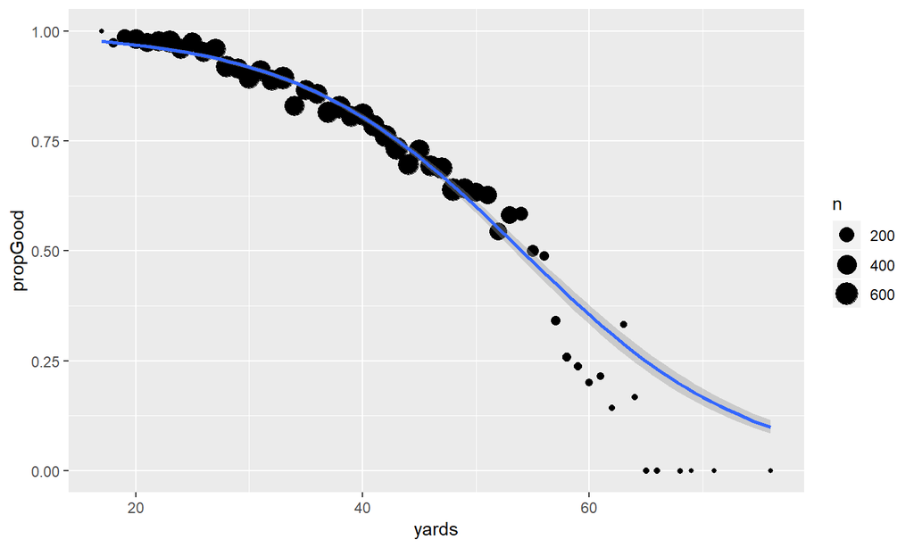

```r
ggplot(distSum, aes(x = yards, y = propGood)) + geom_point(stat = "identity", aes( size = n)) +
    stat_smooth(data = FGData, aes(x = yards, y = good), method = "glm",
                            method.args = list(family = "binomial"))
```

## Logistic Regression

- Still predict with `predict`

```r
#predict probability for given yards
predict(glmFit, newdata = data.frame(yards = c(50, 60)), type = "response", se.fit = TRUE)
```

```
## $fit
##         1         2
## 0.6002763 0.3542034
##
## $se.fit
##           1           2
## 0.006884364 0.011144365
##
## $residual.scale
## [1] 1
```

## Logistic Regression

- Still predict with `predict`

```r
#predict log odds for given yards
predict(glmFit, newdata = data.frame(yards = c(50, 60)), type = "link")
```

```
##          1          2
##  0.4066166 -0.6006135
```

```r
#predict odds for given yards
exp(predict(glmFit, newdata = data.frame(yards = c(50,60)), type = "link"))
```

```
##         1         2
## 1.5017282 0.5484751
```